# Report on zonal TCM

Jiefeng Kang

2023-02-06

## 1 Introduction

In this report, I apply zonal travel cost model (TCM) to the 4 trailheads respectively, to explore the relationship between visitation rate and travel cost. The method mostly follows the methodology in the report *京都大学, 北海道大学, 甲南大学, 国立環境研究所, 2019. 我が国における自然環境施策への効果的な資源動員に向けた研究研究報告書.*

## 2 Method

### 2.1 旅費計算

The travel cost was calculated as the transportation cost. I assume all the visitors go to the trail heads by car. The formula and assumptions are as follows.

$$TC_{ij} = D_{ij} \times E_{ij} \times
P_{ij}$$

where $i$ is the home prefecture; $j$ is the target trail head; $D$ is travel distance, which is assumed to be the best route between home prefecture $i$ and the trail head $j$; $E$ is the gasoline efficiency is 21.7 km/L (according to 国土交通省, that is 平成26年度ガソリン乗用車のJC08モード燃費); $P$ is price for gasoline is 126 Yen/L (according to 総務省’s investigation, that is 2016年7月~9月における静岡県のガソリン販売平均価格).

Of course there are some **bugs**. (1) The variables in the assumption should be updated, for example, updated to the values in 2018 and 2019. (2) Should include opportunity cost into travel cost. For example, the travel cost of a prefecture = transportation cost + opportunity cost, among which, opportunity cost = 1/3 * average income of the prefecture. (3) I didn’t include 高速道路利用料金 in the transportation cost. (4) It is not reasonable to assume that all visitors go to the trail heads by car. It makes sense to follow the previous report to assume that visitors from some prefectures go to Fujisan by flight first. The best practice is to extract the transportation mode of all the visitors. However, that is very challenging (I tried and reported the results before).

The results of travel cost for all pairs of home prefecture - trail head:

| src_loc | trailhead | duration | distance | trv_cost |
| --- | --- | --- | --- | --- |
| 北海道 | yoshida | 989.26833 | 1185.5381 | 13767.5392 |
| 青森県 | yoshida | 658.04833 | 836.7903 | 9717.5648 |
| 岩手県 | yoshida | 523.73500 | 644.4289 | 7483.6905 |
| 宮城県 | yoshida | 391.43000 | 467.3929 | 5427.7885 |
| 秋田県 | yoshida | 523.65167 | 658.2920 | 7644.6813 |
| 山形県 | yoshida | 384.55667 | 470.7118 | 5466.3306 |
| 福島県 | yoshida | 324.82333 | 388.8024 | 4515.1246 |
| 茨城県 | yoshida | 224.81500 | 242.2972 | 2813.7739 |
| 栃木県 | yoshida | 211.02000 | 232.7346 | 2702.7244 |
| 群馬県 | yoshida | 179.47167 | 194.4844 | 2258.5285 |
| 埼玉県 | yoshida | 152.76167 | 143.1338 | 1662.1990 |
| 千葉県 | yoshida | 176.97000 | 178.7580 | 2075.8994 |
| 東京都 | yoshida | 128.53500 | 131.2487 | 1524.1785 |
| 神奈川県 | yoshida | 126.18667 | 138.0824 | 1603.5375 |
| 山梨県 | yoshida | 65.31833 | 67.2926 | 781.4625 |
| 長野県 | yoshida | 197.57000 | 221.5352 | 2572.6668 |
| 新潟県 | yoshida | 331.52000 | 402.7076 | 4676.6044 |
| 富山県 | yoshida | 244.61500 | 291.7008 | 3387.4932 |
| 石川県 | yoshida | 282.96167 | 339.6450 | 3944.2645 |
| 福井県 | yoshida | 324.59667 | 402.6747 | 4676.2223 |
| 岐阜県 | yoshida | 243.69500 | 306.9690 | 3564.8013 |
| 静岡県 | yoshida | 105.78500 | 111.0734 | 1289.8846 |
| 愛知県 | yoshida | 214.55000 | 273.9148 | 3180.9461 |
| 三重県 | yoshida | 257.20000 | 327.1709 | 3799.4040 |
| 滋賀県 | yoshida | 290.94167 | 378.7166 | 4397.9992 |
| 京都府 | yoshida | 305.15500 | 388.9094 | 4516.3672 |
| 大阪府 | yoshida | 331.06333 | 432.9955 | 5028.3348 |
| 兵庫県 | yoshida | 354.17000 | 455.3437 | 5287.8623 |
| 奈良県 | yoshida | 303.47000 | 393.4159 | 4568.7008 |
| 和歌山県 | yoshida | 368.54667 | 482.4868 | 5603.0725 |

[output cut: 158 more lines]

### 2.2 Visitation rate

As stated in the report *Report_20230112_trailhead_choice.html*, I extracted the route of all the dailyid, and categorized them into different groups. Part of the results of the extracted route of some dailyid is as follows.

| dailyid | route | start_time | end_time | date |
| --- | --- | --- | --- | --- |
| 0000a8c0885e2f69d549612474bcfaba56ae4ad841cfdb1ab1b3930f0cdcbb5908c984126d063daf42d820537de70c9f | outside_data_nps_data_nps_data_nps_data_nps_data_nps_outside_nps_fujinomiya_nps_data_nps_data_nps_data_nps_outside_nps_data_outside | 2019-07-29 00:01:00 | 2019-07-29 15:58:00 | 2019-07-29 |
| 000389988157c616ce28c1a941a6c9d18e4c8197fab2782af218626e86064b41d2d5daddd1c68b806399fafb0643f4d6 | outside_data | 2018-07-31 02:03:00 | 2018-07-31 22:12:00 | 2018-07-31 |
| 0003d014f6412cd962539d9bdb334dbe3c2f8da3b9bbd65b8560c00022bef9a46332c0caadca91e1cac0f7c86b3cca9e | outside_yoshida_nps | 2019-08-11 13:01:00 | 2019-08-11 15:50:00 | 2019-08-11 |
| 000551b060379a803c38bd5d9f20d8de20850d5d54ddcb906802c42646968e81a3f14dfd3c4627c5d7fe1416c92eccf3 | outside_data_Gotenba_nps_Gotenba_data_outside | 2019-08-11 00:00:00 | 2019-08-11 20:20:00 | 2019-08-11 |
| 00072b3b8a79ccfde27924174cdb486712d2f257bfaa8bc401042d15b9177e7936741b021a8de2b22285956ec93ff480 | outside | 2018-08-07 05:45:00 | 2018-08-07 05:45:00 | 2018-08-07 |
| 0007d226afa2ac439b3863a0316fb6418639d4a97ed17c7874845920225e12d82ad6b29dc90c4dd90053906b99df2c82 | outside_data_nps_data_outside_nps_fujinomiya_nps_Gotenba_nps_data_nps | 2018-08-12 07:39:00 | 2018-08-12 17:38:00 | 2018-08-12 |
| 0007f63ba021cf3cdcf19a27f7fe760b0d5bdb2539cea8601435de68b0514a8c6c6dbb4fdf4b57b7672b7cd2aedf6c2c | outside_subashiri_nps_outside_nps | 2019-07-12 00:11:00 | 2019-07-12 22:49:00 | 2019-07-12 |
| 0009720f43c9cb56d0b14dce85cf56f41b187ff62aff204b83c11ac99d3a081371c21f469763ce11fc9db7f07bfe8ce2 | nps_data_nps_top_nps_data_nps_data_Gotenba_outside_Gotenba_outside | 2018-07-16 00:12:00 | 2018-07-16 10:33:00 | 2018-07-16 |
| 000ce606602a2af0fac480cd656d325b5389743b21fc472203155e08c3cf01b8d1b3b88da52373a3da59437ec929c023 | outside_data_outside_subashiri_nps_subashiri_nps_outside_nps_outside_subashiri_outside_nps_subashiri_outside_data_outside | 2019-08-17 00:03:00 | 2019-08-17 13:08:00 | 2019-08-17 |
| 000cee1aaf514d2c7289a2926b643a33fdc8511f818e4d97c2561852682dcee59bfac76db893ff23dd8c46c220717734 | outside_nps_outside_nps_outside_nps_outside_nps_outside_nps_outside_nps_outside_nps_outside_nps_outside_nps_outside_nps_outside_nps_outside_nps_outside_nps_outside_nps_outside_nps_outside_nps_outside_… | 2019-08-16 00:05:00 | 2019-08-16 23:53:00 | 2019-08-16 |
| 000d44bb655d63e0b9d45db09d81ab8b1619b78071960a6b4edaa1a1c2fbfb33b3c98f3d9d3cf3bcfb56dcb7a7ebb639 | outside_data_nps_fujinomiya_nps_top_nps_top_nps_fujinomiya_nps_fujinomiya_nps_data_nps_outside | 2018-08-31 00:00:00 | 2018-08-31 16:23:00 | 2018-08-31 |
| 000f22af22b399e08cbb7ddcb80c996178eea2cc85e30c098497bd987f3b65fca2ee709c518f8bb168276db4fd615320 | outside_nps | 2019-08-12 09:37:00 | 2019-08-12 19:11:00 | 2019-08-12 |
| 00140124b424f5bceb37e009c5f119c7fc6668f17833806c93afb76133576e373927f20c5f462748e8dd0b834184e5dc | outside_data_Gotenba_data_outside | 2019-08-26 00:52:00 | 2019-08-26 13:09:00 | 2019-08-26 |
| 00167a1b9057effc09bfa2f1c8994c0f946de68bdacb049133e79cd2280ada9eae1d378ae529ceb5291d3f9e609d9690 | outside_nps_fujinomiya_nps_fujinomiya_nps | 2018-07-05 03:38:00 | 2018-07-05 21:38:00 | 2018-07-05 |
| 0018b041936a550b2911eeba05baf25a9171c625e27e612c5118a1ccd39ffe5fa9b6b3fb7159ba02e6a506ffcda2e9a5 | outside_nps_outside | 2018-07-10 00:02:00 | 2018-07-10 13:13:00 | 2018-07-10 |
| 001b39b05758be231badbcddbb015d68772d8d02d98417a80fe76ba68db299798463667d48173147058b9f52c7affaea | nps_yoshida_nps_outside | 2019-08-05 02:09:00 | 2019-08-05 11:00:00 | 2019-08-05 |
| 001bf7cdc0ec65bdcef9d3479e0621a8b8932c7d092f3dc05a520db6b0b9708b898a49c87fccd90e489a0a524d96d675 | outside_nps | 2019-08-30 00:00:00 | 2019-08-30 11:34:00 | 2019-08-30 |
| 001d3dc98720f16637fcc899efff087b90c71fcff4b0cff29c0c51195ea56e7d740cc1b01f10bbb6c246fdbff2c5663b | outside | 2018-08-17 07:44:00 | 2018-08-17 07:44:00 | 2018-08-17 |
| 001f4ef20dd22d80f512004af3cdd058bab7ad450a693ca9b00bb2f019bcef67356440c03d2af5b9b63d4b13dd336e00 | outside_nps_outside | 2018-07-08 00:19:00 | 2018-07-08 07:41:00 | 2018-07-08 |
| 00214a86d4a06be9afc99cbb0bbf7248009b16031b9236d047c567ac6ec758f0d5ee016627d6b8ea6221a77d16c3293f | outside_data_outside_data_outside_data_outside_data_outside_data_outside | 2019-08-19 00:03:00 | 2019-08-19 17:12:00 | 2019-08-19 |
| 00225871039a06e2b64c6b23a78fe8d1d66ef1e4f9b16487ccacc903faa51800bb17fced76089e9b76eb6535426ff2bb | nps_outside_nps_top_nps_top_nps_top_data_top_nps_top_nps_top_nps_outside_subashiri_outside | 2019-08-06 00:01:00 | 2019-08-06 10:53:00 | 2019-08-06 |
| 002277b3e18ee87604032ed70a03bf80974800a8fae4e6312dc66ce229997ae7133e64c2f1beefdf841518780ab2787c | outside_data_outside_data_outside_data_outside | 2018-07-12 01:19:00 | 2018-07-12 23:36:00 | 2018-07-12 |
| 0023f5497918fa7ac7d208863343df602cf90ffdd53124a8322af46ec652bd80a3d9f5c0b991f2ce318ae773610e428c | outside_data_Gotenba | 2019-08-03 06:44:00 | 2019-08-03 23:59:00 | 2019-08-03 |
| 0025e15709719fae42c68a8229b1da4219be7d4cbf84dfab033bf79e7868530fd4d52099037682a2f288cbad1c0b63f4 | outside | 2019-07-25 00:00:00 | 2019-07-25 00:00:00 | 2019-07-25 |
| 002737fb34656237e92394f7b253e08f4ab387ff44459de788d4501e9e508e52f18f07e314835c51e931b19f0d9f2fbe | outside_data_outside | 2018-07-18 06:40:00 | 2018-07-18 21:10:00 | 2018-07-18 |
| 002773547248138da37b6f95014bfd0aed2645c984113dafbf00cd32567b8d3683d35be2b95a3422641948b46874892e | outside_nps_outside | 2018-08-14 00:00:00 | 2018-08-14 09:52:00 | 2018-08-14 |
| 00285b9201b930d3bce5fd122eabc2568f0a0b506c2470e1c5f9879b364580c3ad352c742ce4d50e07ed36b0d500c4f7 | outside_nps_outside_data_nps_outside | 2019-08-02 00:05:00 | 2019-08-02 17:48:00 | 2019-08-02 |
| 00289950be8db5eeb8b8c08f47ebad78f123d54386d16150cd1017afca9692afa00a3b1c54b8b7e40b7ab60886139819 | outside_data_outside_data_outside | 2019-08-25 00:04:00 | 2019-08-25 16:03:00 | 2019-08-25 |
| 0029ab6b2bdc985d8bf1facd1d8dcaa744265738552f6aec6ccddc4e2b808cc8d89d58fa3445edea9273b1834469dbe3 | outside_yoshida_outside | 2019-08-06 11:09:00 | 2019-08-06 20:51:00 | 2019-08-06 |
| 002a03a321d1c7901fa09eb29785d40c63e42842d7fbef573b71103fb028d3f6f1acf64a1a9b6f02b86b282ffb7aa9ca | outside | 2018-08-14 05:33:00 | 2018-08-14 05:33:00 | 2018-08-14 |

[output cut: 70 more lines]

The result was summarized by each pair of home prefecture - trail head, so that we can get the number of dailyid (visitation) for each pair. The population data of each prefecture is from [総務省統計局](https://www.stat.go.jp/data/jinsui/2019np/index.html). Then the visitation rate was calculated as:

$$VR_{ijk} = V_{ijk} / P_{ik}$$

where $i$ is the home prefecture; $j$ is the target trail head; $k$ is year (2018 or 2019); $VR$ is the visitation rate (unit: /1000); $V$ is the number of visitations = number of dailyid, here I assumes that the visitation turnover rate is 0; $P$ is the population of the prefecture $i$.

The results is shown as follows.

| year | prefname | trailhead | V | P | VR |
| --- | --- | --- | --- | --- | --- |
| 2018 | 三重県 | fujinomiya | 17 | 1791000 | 0.0094919 |
| 2018 | 三重県 | Gotenba | 3 | 1791000 | 0.0016750 |
| 2018 | 三重県 | subashiri | 2 | 1791000 | 0.0011167 |
| 2018 | 三重県 | yoshida | 36 | 1791000 | 0.0201005 |
| 2018 | 京都府 | fujinomiya | 37 | 2591000 | 0.0142802 |
| 2018 | 京都府 | Gotenba | 10 | 2591000 | 0.0038595 |
| 2018 | 京都府 | subashiri | 8 | 2591000 | 0.0030876 |
| 2018 | 京都府 | yoshida | 66 | 2591000 | 0.0254728 |
| 2018 | 佐賀県 | fujinomiya | 3 | 819000 | 0.0036630 |
| 2018 | 佐賀県 | Gotenba | 1 | 819000 | 0.0012210 |
| 2018 | 佐賀県 | yoshida | 8 | 819000 | 0.0097680 |
| 2018 | 兵庫県 | fujinomiya | 101 | 5484000 | 0.0184172 |
| 2018 | 兵庫県 | Gotenba | 32 | 5484000 | 0.0058352 |
| 2018 | 兵庫県 | subashiri | 11 | 5484000 | 0.0020058 |
| 2018 | 兵庫県 | yoshida | 80 | 5484000 | 0.0145879 |
| 2018 | 北海道 | fujinomiya | 12 | 5286000 | 0.0022701 |
| 2018 | 北海道 | Gotenba | 4 | 5286000 | 0.0007567 |
| 2018 | 北海道 | subashiri | 3 | 5286000 | 0.0005675 |
| 2018 | 北海道 | yoshida | 29 | 5286000 | 0.0054862 |
| 2018 | 千葉県 | fujinomiya | 85 | 6255000 | 0.0135891 |
| 2018 | 千葉県 | Gotenba | 47 | 6255000 | 0.0075140 |
| 2018 | 千葉県 | subashiri | 35 | 6255000 | 0.0055955 |
| 2018 | 千葉県 | yoshida | 426 | 6255000 | 0.0681055 |
| 2018 | 和歌山県 | fujinomiya | 4 | 935000 | 0.0042781 |
| 2018 | 和歌山県 | Gotenba | 1 | 935000 | 0.0010695 |
| 2018 | 和歌山県 | yoshida | 18 | 935000 | 0.0192513 |
| 2018 | 埼玉県 | fujinomiya | 94 | 7330000 | 0.0128240 |
| 2018 | 埼玉県 | Gotenba | 64 | 7330000 | 0.0087312 |
| 2018 | 埼玉県 | subashiri | 52 | 7330000 | 0.0070941 |
| 2018 | 埼玉県 | yoshida | 415 | 7330000 | 0.0566166 |

[output cut: 300 more lines]

### 2.3 Model

Now we have got the dependent variable (visitation rate) and independent variable (travel cost), we can explore the relationship between them. I used linear model for the analysis. There are 4 choices based of the model:

$$VR = \alpha + \beta \times TC$$
$$log(VR) = \alpha + \beta \times TC$$
$$VR = \alpha + \beta \times log(TC)$$
$$log(VR) = \alpha + \beta \times
log(TC)$$

where VR is visitation rate, TC is travel cost. Again, I followed the report *京都大学, 北海道大学, 甲南大学, 国立環境研究所, 2019. 我が国における自然環境施策への効果的な資源動員に向けた研究研究報告書.*, used $log(VR) = \alpha + \beta \times TC$ in this analysis.

The regression model was applied to the whole dataset and sub-dataset for each pair of home prefecture - trail head respectively.

## 3 Results

### 3.1 Whole dataset

There are 330 observations in the whole dataset:

| year | prefname | trailhead | V | P | VR | TC |
| --- | --- | --- | --- | --- | --- | --- |
| 2018 | 三重県 | fujinomiya | 17 | 1791000 | 0.0094919 | 3519.4285 |
| 2018 | 三重県 | Gotenba | 3 | 1791000 | 0.0016750 | 3415.5697 |
| 2018 | 三重県 | subashiri | 2 | 1791000 | 0.0011167 | 3660.7366 |
| 2018 | 三重県 | yoshida | 36 | 1791000 | 0.0201005 | 3799.4040 |
| 2018 | 京都府 | fujinomiya | 37 | 2591000 | 0.0142802 | 4236.3917 |
| 2018 | 京都府 | Gotenba | 10 | 2591000 | 0.0038595 | 4132.5329 |
| 2018 | 京都府 | subashiri | 8 | 2591000 | 0.0030876 | 4377.6999 |
| 2018 | 京都府 | yoshida | 66 | 2591000 | 0.0254728 | 4516.3672 |
| 2018 | 佐賀県 | fujinomiya | 3 | 819000 | 0.0036630 | 11991.9054 |
| 2018 | 佐賀県 | Gotenba | 1 | 819000 | 0.0012210 | 11888.0466 |
| 2018 | 佐賀県 | yoshida | 8 | 819000 | 0.0097680 | 12271.8809 |
| 2018 | 兵庫県 | fujinomiya | 101 | 5484000 | 0.0184172 | 5007.8868 |
| 2018 | 兵庫県 | Gotenba | 32 | 5484000 | 0.0058352 | 4904.0268 |
| 2018 | 兵庫県 | subashiri | 11 | 5484000 | 0.0020058 | 5149.1938 |
| 2018 | 兵庫県 | yoshida | 80 | 5484000 | 0.0145879 | 5287.8623 |
| 2018 | 北海道 | fujinomiya | 12 | 5286000 | 0.0022701 | 14173.7028 |
| 2018 | 北海道 | Gotenba | 4 | 5286000 | 0.0007567 | 13969.7628 |
| 2018 | 北海道 | subashiri | 3 | 5286000 | 0.0005675 | 13723.1013 |
| 2018 | 北海道 | yoshida | 29 | 5286000 | 0.0054862 | 13767.5392 |
| 2018 | 千葉県 | fujinomiya | 85 | 6255000 | 0.0135891 | 2050.4021 |
| 2018 | 千葉県 | Gotenba | 47 | 6255000 | 0.0075140 | 1846.4632 |
| 2018 | 千葉県 | subashiri | 35 | 6255000 | 0.0055955 | 1882.7361 |
| 2018 | 千葉県 | yoshida | 426 | 6255000 | 0.0681055 | 2075.8994 |
| 2018 | 和歌山県 | fujinomiya | 4 | 935000 | 0.0042781 | 5323.0970 |
| 2018 | 和歌山県 | Gotenba | 1 | 935000 | 0.0010695 | 5219.2382 |
| 2018 | 和歌山県 | yoshida | 18 | 935000 | 0.0192513 | 5603.0725 |
| 2018 | 埼玉県 | fujinomiya | 94 | 7330000 | 0.0128240 | 1873.9231 |
| 2018 | 埼玉県 | Gotenba | 64 | 7330000 | 0.0087312 | 1669.9831 |
| 2018 | 埼玉県 | subashiri | 52 | 7330000 | 0.0070941 | 1706.2572 |
| 2018 | 埼玉県 | yoshida | 415 | 7330000 | 0.0566166 | 1662.1990 |

[output cut: 300 more lines]

Let’s make a plot for the data first:

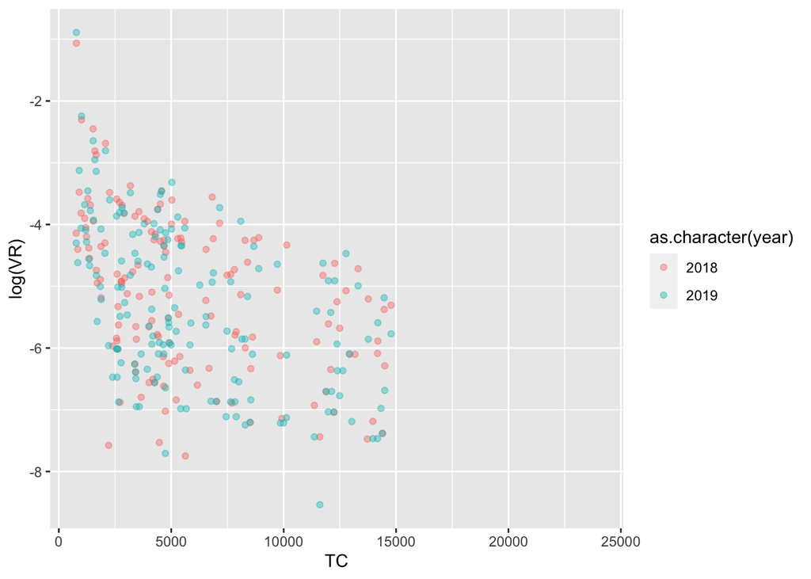

The results of the regression:

```
##
## Call:
## lm(formula = log(VR) ~ TC, data = zone_raw_tar)
##
## Residuals:
##     Min      1Q  Median      3Q     Max
## -2.9107 -0.8908 -0.0424  0.9276  3.5503
##
## Coefficients:
##               Estimate Std. Error t value Pr(>|t|)
## (Intercept) -4.3175056  0.1170366 -36.890   <2e-16 ***
## TC          -0.0001573  0.0000166  -9.479   <2e-16 ***
## ---
## Signif. codes:  0 '***' 0.001 '**' 0.01 '*' 0.05 '.' 0.1 ' ' 1
##
## Residual standard error: 1.13 on 306 degrees of freedom
##   (22 observations deleted due to missingness)
## Multiple R-squared:  0.227,  Adjusted R-squared:  0.2244
## F-statistic: 89.84 on 1 and 306 DF,  p-value: < 2.2e-16
```

With no surprise, the p value for the model is < 0.001, the estimate for travel cost is negative (-0.0001573) which means visitation rate decreases with increasing travel cost.

However, for the methodology, there are some **questions**.

1. For any statistical analysis, there are some assumptions (e.g., normal distribution), but I haven’t test the assumptions yet.
2. When applying traditional statistical analysis to big data, there can be some problem. One of them is that the p value is likely to be always significant, and for big data, it could be more reasonable to focus on effect size at the same time (rather than just focus on p value, see “Big data studies can identify significant but inconsequential effects” section of *Kaplan, R.M., Chambers, D.A., Glasgow, R.E., 2014. Big Data and Large Sample Size: A Cautionary Note on the Potential for Bias. Clinical and Translational Science 7, 342–346. https://doi.org/10.1111/cts.12178* for more details).

### 3.2 For each pair of prefecture - trail head

Similarly, the regression was applied to the sub-dataset for each trail head. To Yoshida trail head:

```
##
## Call:
## lm(formula = log(VR) ~ TC, data = zone_raw_tar)
##
## Residuals:
##      Min       1Q   Median       3Q      Max
## -1.37148 -0.34623 -0.02377  0.35073  2.23702
##
## Coefficients:
##               Estimate Std. Error t value Pr(>|t|)
## (Intercept) -2.984e+00  1.195e-01  -24.96   <2e-16 ***
## TC          -1.831e-04  1.599e-05  -11.45   <2e-16 ***
## ---
## Signif. codes:  0 '***' 0.001 '**' 0.01 '*' 0.05 '.' 0.1 ' ' 1
##
## Residual standard error: 0.5954 on 88 degrees of freedom
##   (6 observations deleted due to missingness)
## Multiple R-squared:  0.5984, Adjusted R-squared:  0.5938
## F-statistic: 131.1 on 1 and 88 DF,  p-value: < 2.2e-16
```

To Subashiri trail head:

```
##
## Call:
## lm(formula = log(VR) ~ TC, data = zone_raw_tar)
##
## Residuals:
##      Min       1Q   Median       3Q      Max
## -2.04462 -0.47907 -0.02961  0.50949  1.66393
##
## Coefficients:
##               Estimate Std. Error t value Pr(>|t|)
## (Intercept) -5.138e+00  1.614e-01 -31.832  < 2e-16 ***
## TC          -1.778e-04  2.545e-05  -6.988 2.26e-09 ***
## ---
## Signif. codes:  0 '***' 0.001 '**' 0.01 '*' 0.05 '.' 0.1 ' ' 1
##
## Residual standard error: 0.7419 on 62 degrees of freedom
##   (5 observations deleted due to missingness)
## Multiple R-squared:  0.4406, Adjusted R-squared:  0.4315
## F-statistic: 48.83 on 1 and 62 DF,  p-value: 2.26e-09
```

To Gotemba trail head:

```
##
## Call:
## lm(formula = log(VR) ~ TC, data = zone_raw_tar)
##
## Residuals:
##     Min      1Q  Median      3Q     Max
## -1.8561 -0.5484  0.1108  0.4908  2.0374
##
## Coefficients:
##               Estimate Std. Error t value Pr(>|t|)
## (Intercept) -5.001e+00  1.657e-01 -30.174  < 2e-16 ***
## TC          -1.794e-04  2.433e-05  -7.376  3.2e-10 ***
## ---
## Signif. codes:  0 '***' 0.001 '**' 0.01 '*' 0.05 '.' 0.1 ' ' 1
##
## Residual standard error: 0.7903 on 67 degrees of freedom
##   (6 observations deleted due to missingness)
## Multiple R-squared:  0.4482, Adjusted R-squared:  0.4399
## F-statistic: 54.41 on 1 and 67 DF,  p-value: 3.2e-10
```

To Fujinomiya trail head:

```
##
## Call:
## lm(formula = log(VR) ~ TC, data = zone_raw_tar)
##
## Residuals:
##      Min       1Q   Median       3Q      Max
## -2.25395 -0.46792  0.07024  0.62997  1.97749
##
## Coefficients:
##               Estimate Std. Error t value Pr(>|t|)
## (Intercept) -4.036e+00  1.683e-01 -23.981  < 2e-16 ***
## TC          -1.844e-04  2.312e-05  -7.977 7.22e-12 ***
## ---
## Signif. codes:  0 '***' 0.001 '**' 0.01 '*' 0.05 '.' 0.1 ' ' 1
##
## Residual standard error: 0.826 on 83 degrees of freedom
##   (5 observations deleted due to missingness)
## Multiple R-squared:  0.434,  Adjusted R-squared:  0.4272
## F-statistic: 63.64 on 1 and 83 DF,  p-value: 7.216e-12
```